# STAT 432 Homework 06

Spring 2018 - Kevin Wong - kjwong2

Due:** Friday, March 16, 11:59 PM

Please see the [homework policy document](https://daviddalpiaz.github.io/stat432sp18/homework_policy.html) for detailed instructions and some grading notes. Failure to follow instructions will result in point reductions.

> “Nobody actually creates perfect code the first time around, except me. But there’s only one of me.”

> — **[Linus Torvalds](https://en.wikipedia.org/wiki/Linus_Torvalds)**

For this homework, you may only use the following packages:

```r
# general
library(MASS)
library(caret)
library(tidyverse)
library(knitr)
library(kableExtra)
library(mlbench)

# specific
library(randomForest)
library(gbm)
library(klaR)
library(ellipse)
```

If you feel additional general packages would be useful for future homework, please pass these along to the instructor.

You should use the `caret` package and training pipeline to complete this homework. **Any time you use the `train()` function, first run `set.seed(1337)`.**

# Exercise 1 (Tuning KNN Regression with `caret`)

**[6 points]** For this exercise we will train KNN regression models for the `Boston` data from the `MASS` package. Use `medv` as the response and all other variables as predictors. Use the test-train split given below. When tuning models and reporting cross-validated error, use 5-fold cross-validation.

```r
data(Boston, package = "MASS")
set.seed(1)
bstn_idx = createDataPartition(Boston$medv, p = 0.75, list = FALSE)
bstn_trn = Boston[bstn_idx, ]
bstn_tst = Boston[-bstn_idx, ]
```

Consider $k \in \{1, 5, 10, 15, 20, 25, 30, 35\}$ and two pre-processing setups:

- Do **not** scale the predictors.
- **Do** scale the predictors.

Provide plots of cross-validated error versus tuning parameters for both KNN pre-processing setups. Use the same value on the $y$ axis for both plots. (You can be lazy and let `caret` create these plots. Since it will use `lattice` plotting, putting them side-by-side, or on the same plot would be difficult.)

**Answer:**

```r
set.seed(1337)
ex1_mod_knn_scale_no = train(
  form = medv ~ .,
  data = bstn_trn,
  method = "knn",
  trControl = trainControl(method = "cv", number = 5),
  tuneGrid = expand.grid(k = c(1, 5, 10, 15, 20, 25, 30, 35))
)
```

```r
set.seed(1337)
ex1_mod_knn_scale_yes = train(
  form = medv ~ .,
  data = bstn_trn,
  method = "knn",
  preProcess = c("center", "scale"),
  trControl = trainControl(method = "cv", number = 5),
  tuneGrid = expand.grid(k = c(1, 5, 10, 15, 20, 25, 30, 35))
)
```

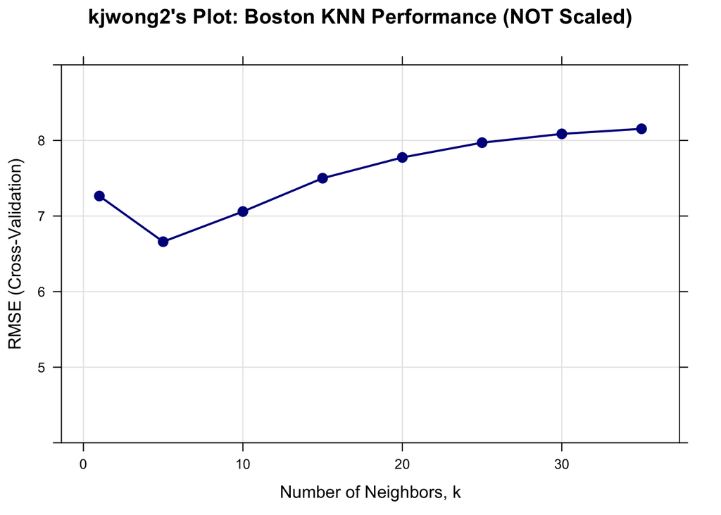

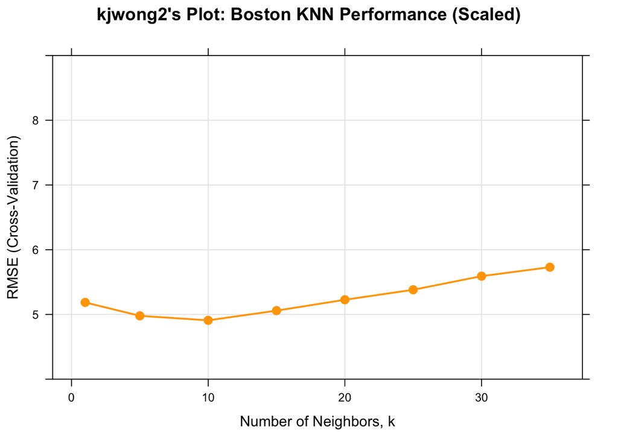

# Exercise 2 (More Regression with `caret`)

**[7 points]** For this exercise we will train more regression models for the `Boston` data from the `MASS` package. Use `medv` as the response and all other variables as predictors. Use the test-train split given previously. When tuning models and reporting cross-validated error, use 5-fold cross-validation.

Traing a total of three new models:

- An additive linear regression
- A random forest
  - Use the default tuning parameters chosen by `caret`
- A boosted tree model (Use `gbm`)
  - Use the provided tuning grid below

```r
gbm_grid = expand.grid(interaction.depth = c(1, 2, 3),
                       n.trees = (1:20) * 100,
                       shrinkage = c(0.1, 0.3),
                       n.minobsinnode = 20)
```

Provide plots of error versus tuning parameters for the the boosted tree model. Also provide a table that summarizes the cross-validated and test RMSE for each of the three (tuned) models as well as the two models tuned in the previous exercise.

**Answer:**

```r
set.seed(1337)
ex2_mod_lm = train(
  form = medv ~ .,
  data = bstn_trn,
  method = "lm",
  trControl = trainControl(method = "cv", number = 5)
)
```

```r
set.seed(1337)
ex2_mod_rf = train(
  form = medv ~ .,
  data = bstn_trn,
  method = "rf",
  trControl = trainControl(method = "cv", number = 5)
)
```

```r
set.seed(1337)
ex2_mod_gbm = train(
  form = medv ~ .,
  data = bstn_trn,
  method = "gbm",
  trControl = trainControl(method = "cv", number = 5),
  tuneGrid = gbm_grid,
  verbose = FALSE
)
```

```r
calc_rmse = function(actual, predicted) {
  sqrt(mean((actual - predicted) ^ 2))
}

get_best_result = function(caret_fit) {
  best = which(rownames(caret_fit$results) == rownames(caret_fit$bestTune))
  best_result = caret_fit$results[best, ]
  rownames(best_result) = NULL
  best_result
}

ex2_cv_rmses = c(
  get_best_result(ex1_mod_knn_scale_no)$RMSE,
  get_best_result(ex1_mod_knn_scale_yes)$RMSE,
  get_best_result(ex2_mod_lm)$RMSE,
  get_best_result(ex2_mod_rf)$RMSE,
  get_best_result(ex2_mod_gbm)$RMSE
)

ex2_test_rmses = c(
  calc_rmse(bstn_tst$medv, predict(ex1_mod_knn_scale_no, bstn_tst)),
  calc_rmse(bstn_tst$medv, predict(ex1_mod_knn_scale_yes, bstn_tst)),
  calc_rmse(bstn_tst$medv, predict(ex2_mod_lm, bstn_tst)),
  calc_rmse(bstn_tst$medv, predict(ex2_mod_rf, bstn_tst)),
  calc_rmse(bstn_tst$medv, predict(ex2_mod_gbm, bstn_tst))
)
```

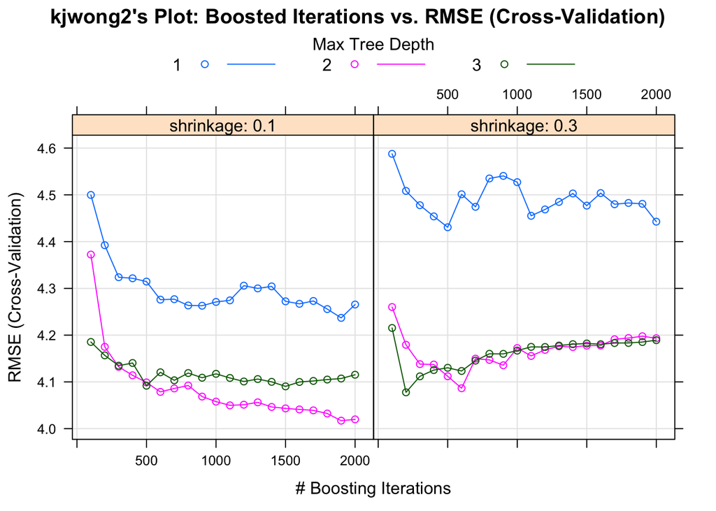

| Model Name | Method | Cross-Validation RMSE | Test RMSE |
| --- | --- | --- | --- |
| ex1_mod_knn_scale_no | KNN (Unscaled) | 6.660057 | 6.013595 |
| ex1_mod_knn_scale_yes | KNN (Scaled) | 4.909014 | 4.283984 |
| ex2_mod_lm | Additive Linear Regression | 4.921781 | 4.608329 |
| ex2_mod_rf | Random Forest | 3.563629 | 3.255258 |
| ex2_mod_gbm | Boosted Tree Model | 4.017039 | 3.588216 |

# Exercise 3 (Clasification with `caret`)

**[7 points]** For this exercise we will train a number of classifiers using the training data generated below. The categorical response variable is `classes` and the remaining variables should be used as predictors. When tuning models and reporting cross-validated error, use 10-fold cross-validation. We will not use a test set for this exercise.

```r
set.seed(42)
# simulate data using mlbench
sim_trn = mlbench.2dnormals(n = 500, cl = 7, r = 10, sd = 3)
# create tidy data
sim_trn = data.frame(
  classes = sim_trn$classes,
  sim_trn$x
)
```

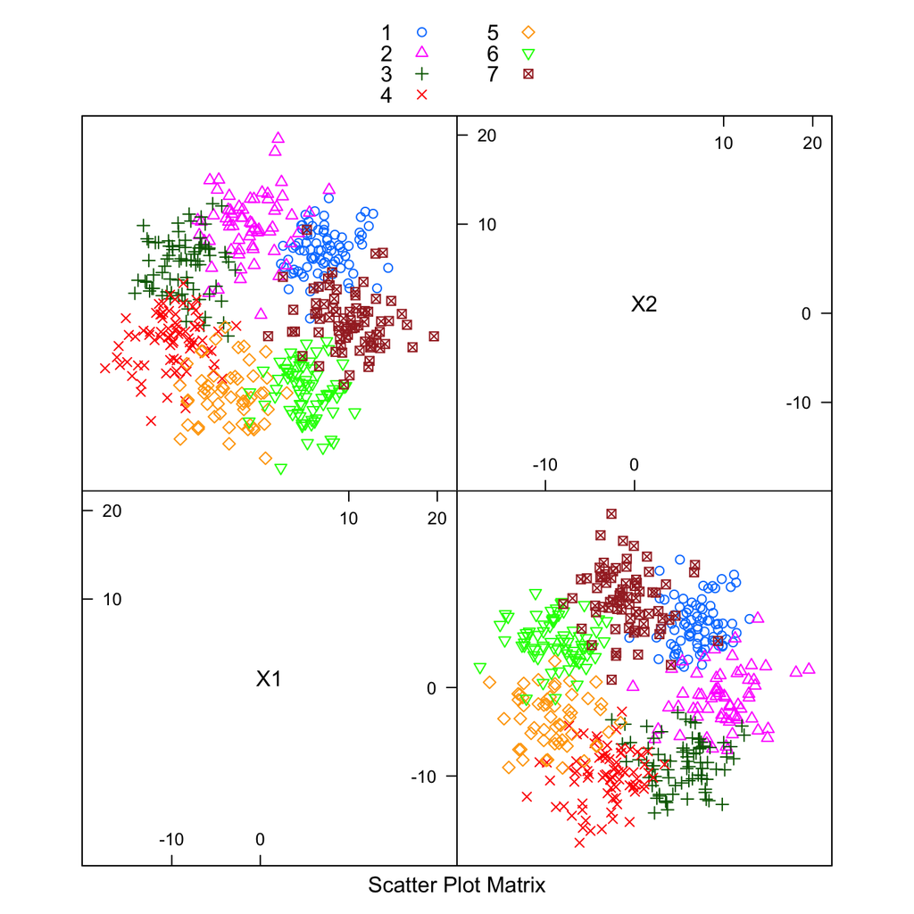

```r
featurePlot(x = sim_trn[, -1],
            y = sim_trn$classes,
            plot = "pairs",
            auto.key = list(columns = 2),
            par.settings = list(superpose.symbol = list(pch = 1:9))
)
```

Fit a total of five models:

- LDA
- QDA
- Naive Bayes
- Regularized Discriminant Analysis (RDA)
  - Use method `rda` with `caret` which requires the `klaR` package
  - Use the default tuning grid
- Random Forest
  - Use a tuning grid that considers `mtry` values of `1` and `2`

Provide a plot of accuracy versus tuning parameters for the RDA model. Also provide a table that summarizes the cross-validated accuracy and their standard deviations for each of the five (tuned) models.

**Answer:**

```r
set.seed(1337)
ex3_mod_lda = train(
  form = classes ~ .,
  data = sim_trn,
  method = "lda",
  trControl = trainControl(method = "cv", number = 10)
)
```

```r
set.seed(1337)
ex3_mod_qda = train(
  form = classes ~ .,
  data = sim_trn,
  method = "qda",
  trControl = trainControl(method = "cv", number = 10)
)
```

```r
set.seed(1337)
ex3_mod_nb = train(
  form = classes ~ .,
  data = sim_trn,
  method = "nb",
  trControl = trainControl(method = "cv", number = 10)
)
```

```r
set.seed(1337)
ex3_mod_rda = train(
  form = classes ~ .,
  data = sim_trn,
  method = "rda",
  trControl = trainControl(method = "cv", number = 10)
)
```

```r
set.seed(1337)
ex3_mod_rf = train(
  form = classes ~ .,
  data = sim_trn,
  method = "rf",
  trControl = trainControl(method = "cv", number = 10),
  tuneGrid = expand.grid(mtry = c(1, 2))
)
```

```r
ex3_cv_accuracies = c(
  get_best_result(ex3_mod_lda)$Accuracy,
  get_best_result(ex3_mod_qda)$Accuracy,
  get_best_result(ex3_mod_nb)$Accuracy,
  get_best_result(ex3_mod_rda)$Accuracy,
  get_best_result(ex3_mod_rf)$Accuracy
)

ex3_accuracy_sds = c(
  get_best_result(ex3_mod_lda)$AccuracySD,
  get_best_result(ex3_mod_qda)$AccuracySD,
  get_best_result(ex3_mod_nb)$AccuracySD,
  get_best_result(ex3_mod_rda)$AccuracySD,
  get_best_result(ex3_mod_rf)$AccuracySD
)
```

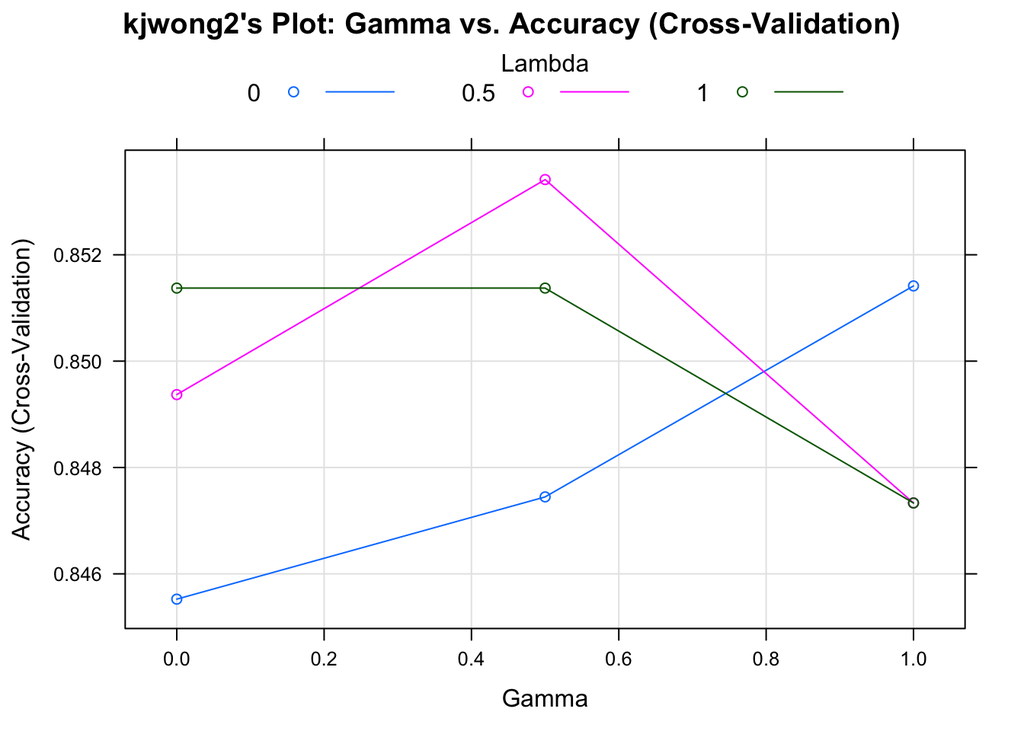

| Model Name | Method | Cross-Validation Accuracy | Standard Deviation |
| --- | --- | --- | --- |
| ex3_mod_lda | LDA | 0.8513737 | 0.0490760 |
| ex3_mod_qda | QDA | 0.8455243 | 0.0553077 |
| ex3_mod_nb | Naive Bayes | 0.8494163 | 0.0524447 |
| ex3_mod_rda | RDA | 0.8534146 | 0.0488233 |
| ex3_mod_rf | Random Forest | 0.8378983 | 0.0685732 |
| *** |  |  |  |

# Exercise 4 (Concept Checks)

**[1 point each]** Answer the following questions based on your results from the three exercises.

## Regression

**(a)** What value of $k$ is chosen for KNN without predictor scaling?

**Answer:**

```r
ex1_mod_knn_scale_no$bestTune
```

```
##   k
## 2 5
```

- k = 5 is the best value of KNN without predictor scaling.

**(b)** What value of $k$ is chosen for KNN **with** predictor scaling?

**Answer:**

```r
ex1_mod_knn_scale_yes$bestTune
```

```
##    k
## 3 10
```

- k = 10 is the best value of KNN with predictor scaling.

**(c)** What are the values of the tuning parameters chosen for the boosted tree regression model?

**Answer:**

```r
ex2_mod_gbm$bestTune
```

```
##    n.trees interaction.depth shrinkage n.minobsinnode
## 39    1900                 2       0.1             20
```

**(d)** Which regression model achieves the lowest cross-validated error?

**Answer:** - The Random Forest model achieves the lowest cross-validation error with an error of 3.5636289

## Classification

**(f)** What are the values of the tuning parameters chosen for the RDA model?

**Answer:**

```r
ex3_mod_rda$bestTune
```

```
##   gamma lambda
## 5   0.5    0.5
```

**(g)** Based on the scatterplot, which method, LDA or QDA, do you think is *more* appropriate? Explain.

**Answer:** - I believe LDA is more appropriate because the scatterplot shows that the data classes have the *same shape* but *different locations*.

**(h)** Based on the scatterplot, which method, QDA or Naive Bayes, do you think is *more* appropriate? Explain.

**Answer:** - I believe Naive Bayes is more appropriate because the scatterplot shows that the data classes have *different locations* but x1 and x2 appear to be *uncorrelated*.

**(i)** Which model achieves the best cross-validated accuracy?

**Answer:** - The RDA model achieves the lowest cross-validation error with an error of 0.8534146

**(j)** Do you believe the model in **(i)** is the model that should be chosen? Explain.

**Answer:** - I believe that this is the best model because it has the highest accuracy AND the lowest standard deviation.